# Analysis of the Population and Economic Impact of Severe Weather Events in the United States

Rhea Lucas

June 1, 2016

For this analysis, we are looking at data for storms and severe weather events. We are particularly interested in the impact they have to population health due to fatalities and injuries that can occur during these events, as well as their impact to the economy as a result of property damage brought by these events.

Data from the U.S. National Oceanic and Atmospheric Administration’s (NOAA) storm database was used in this analysis.

## Data Processing

For the purpose of this study, we are using prepared data that can be downloaded from [here](https://d396qusza40orc.cloudfront.net/repdata%2Fdata%2FStormData.csv.bz2).

We will read in this data using the `read.csv()` function which allows us to read from zipped file. Since the dataset is quite big, it may take some time to read it in.

### Loading and exploring the Data

```r
weatherData <- read.csv("repdata-data-StormData.csv.bz2")
```

Now that we’ve read the data, we can explore how it looks. We see that there’s a total of 902297 observations for 37 variables, with the variable `EVTYPE` providing us information on what type of events were recorded.

Other variables to note are `FATALITIES`, `INJURIES`, `PROPDMG`, `PROPDMGEXP`, `CROPDMG`, `CROPDMGEXP` which looks like relevant variables for our analysis.

```r
names(weatherData)
```

```
##  [1] "STATE__"    "BGN_DATE"   "BGN_TIME"   "TIME_ZONE"  "COUNTY"
##  [6] "COUNTYNAME" "STATE"      "EVTYPE"     "BGN_RANGE"  "BGN_AZI"
## [11] "BGN_LOCATI" "END_DATE"   "END_TIME"   "COUNTY_END" "COUNTYENDN"
## [16] "END_RANGE"  "END_AZI"    "END_LOCATI" "LENGTH"     "WIDTH"
## [21] "F"          "MAG"        "FATALITIES" "INJURIES"   "PROPDMG"
## [26] "PROPDMGEXP" "CROPDMG"    "CROPDMGEXP" "WFO"        "STATEOFFIC"
## [31] "ZONENAMES"  "LATITUDE"   "LONGITUDE"  "LATITUDE_E" "LONGITUDE_"
## [36] "REMARKS"    "REFNUM"
```

```r
nrow(weatherData)
```

```
## [1] 902297
```

Looking deeper into the `EVTYPE`, we can see that there are 985 unique event types in the dataset. However, if we convert EVTYPE to uppercase, we can see that this is reduced to 898, which tells us that there are similar events using different letter cases, and we should probably fix this in our data.

```r
nrow(table(weatherData$EVTYPE))
```

```
## [1] 985
```

```r
nrow(table(toupper(weatherData$EVTYPE)))
```

```
## [1] 898
```

We also have `FATALITIES` and `INJURIES` which we will use to analyze impact on population health. Looking at the summary for these variables, it looks like there are a lot of 0 values in the dataset with the very low mean and 3rd quantile being 0. In fact, if we look at the number of rows that have 0 `FATALITIES` and `INJURIES` we see that 880368 of 902297 (97.6%) of the data has 0 impact to population health.

This is something that we should take note of for our analysis later.

```r
summary(weatherData$FATALITIES)
```

```
##     Min.  1st Qu.   Median     Mean  3rd Qu.     Max.
##   0.0000   0.0000   0.0000   0.0168   0.0000 583.0000
```

```r
summary(weatherData$INJURIES)
```

```
##      Min.   1st Qu.    Median      Mean   3rd Qu.      Max.
##    0.0000    0.0000    0.0000    0.1557    0.0000 1700.0000
```

```r
nrow(weatherData[weatherData$FATALITIES+weatherData$INJURIES==0,])
```

```
## [1] 880368
```

```r
summary(weatherData$PROPDMG)
```

```
##    Min. 1st Qu.  Median    Mean 3rd Qu.    Max.
##    0.00    0.00    0.00   12.06    0.50 5000.00
```

```r
summary(weatherData$CROPDMG)
```

```
##    Min. 1st Qu.  Median    Mean 3rd Qu.    Max.
##   0.000   0.000   0.000   1.527   0.000 990.000
```

```r
nrow(weatherData[weatherData$PROPDMG+weatherData$CROPDMG==0,])
```

```
## [1] 657266
```

Finally, we check `PROPDMGEXP` and `CROPDMGEXP` variables to see what exponents we’re dealing with for property damage as we need to use this for comparing impact to property in our analysis later on.

Looking at the summary for these exponent variables, we see that exponents are either numeric or letters which in indicate a multiplier (i.e. 0=10^0, 1=10^1, H=10^2, K=10^3, etc.).

```r
summary(weatherData$PROPDMGEXP)
```

```
##             -      ?      +      0      1      2      3      4      5
## 465934      1      8      5    216     25     13      4      4     28
##      6      7      8      B      h      H      K      m      M
##      4      5      1     40      1      6 424665      7  11330
```

```r
summary(weatherData$CROPDMGEXP)
```

```
##             ?      0      2      B      k      K      m      M
## 618413      7     19      1      9     21 281832      1   1994
```

We also see that there are signs (-/+/?) in the exponent variables, whose values are a bit harder to deduce so we need to look at the data using these exponents. First, for `?` we see that the property and crop damage are all 0’s so we will assume multiplier for `?` is 0. For `-` and `+`, since there are non-zero values for property damage using this exponent, we will assume multiplier is 10^0 (1).

```r
weatherData[weatherData$PROPDMGEXP=="?", c("PROPDMG", "CROPDMG")]
```

```
##        PROPDMG CROPDMG
## 198689       0       0
## 225254       0       0
## 227409       0       0
## 232016       0       0
## 233746       0       0
## 233747       0       0
## 233748       0       0
## 247617       0       0
```

```r
weatherData[weatherData$PROPDMGEXP=="+", "PROPDMG"]
```

```
## [1] 20 20  2 15 60
```

```r
weatherData[weatherData$PROPDMGEXP=="-", "PROPDMG"]
```

```
## [1] 15
```

### Cleaning the Data

Now that we’ve explored our data, we will clean it up a bit for it to be more useable for our analysis. First, we make sure all values for `EVTYPE` are all in uppercase. We also convert the variable `BGN_DATE` from factor to date to make it easier to extract the year from it later on.

```r
weatherData$BGN_DATE <- as.Date(weatherData$BGN_DATE, "%m/%d/%Y")
weatherData$EVTYPE <- toupper(weatherData$EVTYPE)
```

```r
library(plyr)
expmapping <- data.frame(expValue=c("-", "?", "+", "0", "1", "2", "3", "4",
                                    "5", "6", "7", "8", "B", "H", "K", "M", ""),
                      multiplier=c(10^0, 0, 10^0, 10^0, 10^1, 10^2, 10^3, 10^4,
                                   10^5, 10^6, 10^7, 10^8, 10^9, 10^2, 10^3, 10^6, 10^0))

weatherData$PROPDMGEXP <- mapvalues(toupper(weatherData$PROPDMGEXP),
                                    expmapping$expValue, expmapping$multiplier)
weatherData$CROPDMGEXP <- mapvalues(toupper(weatherData$CROPDMGEXP),
                                    expmapping$expValue, expmapping$multiplier)
weatherData$PROPDMGEXP <- as.numeric(weatherData$PROPDMGEXP)
weatherData$CROPDMGEXP <- as.numeric(weatherData$CROPDMGEXP)
table(weatherData$PROPDMGEXP)
```

```
##
##      0      1     10    100   1000  10000  1e+05  1e+06  1e+07  1e+08
##      8 466156     25     20 424669      4     28  11341      5      1
##  1e+09
##     40
```

```r
table(weatherData$CROPDMGEXP)
```

```
##
##      0      1    100   1000  1e+06  1e+09
##      7 618432      1 281853   1995      9
```

## Results

To find out which event has the most impact to population health, we want to look look at how many injuries and fatalities did each type of event cause. To show this, we create a new `healthSummary` data frame using `dplyr` package which has the sum of `FATALITIES` and `INJURIES` per `EVTYPE`. Since we’re not interested in events which has 0 `FATALITIES` and `INJURIES`` for this analysis, we will remove them from the dataset.

```r
library(dplyr, warn.conflicts = FALSE)

healthSummary <- group_by(weatherData, EVTYPE) %>% #create grouping
                 summarise(TOT_FATALITIES=sum(FATALITIES), TOT_INJURIES=sum(INJURIES),
                           TOT_IMPACT=sum(FATALITIES+INJURIES)) %>%
                 filter(TOT_IMPACT!=0) %>% #filter rows
                 arrange(desc(TOT_IMPACT)) #sort by total impact
healthTop <- healthSummary[1:10,]
```

We will now plot the top 10 event types with the most population health impact based on fatalities and Injuries caused. Based on the plot, we see that Tornadoes, by far have the most impact to population health followed by excessive heat.

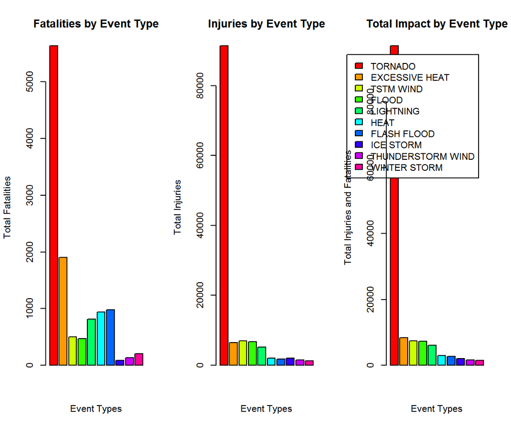

Top 10 Events Impacting Population Health in the United States

```r
par(mfrow=c(1,3))
barplot(healthTop$TOT_FATALITIES, col = rainbow(10),
        xlab="Event Types", ylab="Total Fatalities",
        main="Fatalities by Event Type")
barplot(healthTop$TOT_INJURIES, col = rainbow(10),
        xlab="Event Types", ylab="Total Injuries",
        main="Injuries by Event Type")
barplot(healthTop$TOT_IMPACT, legend.text = healthTop$EVTYPE, col = rainbow(10),
        xlab="Event Types", ylab="Total Injuries and Fatalities",
        main="Total Impact by Event Type")
```

```r
print(healthTop)
```

```
## Source: local data frame [10 x 4]
##
##               EVTYPE TOT_FATALITIES TOT_INJURIES TOT_IMPACT
##                (chr)          (dbl)        (dbl)      (dbl)
## 1            TORNADO           5633        91346      96979
## 2     EXCESSIVE HEAT           1903         6525       8428
## 3          TSTM WIND            504         6957       7461
## 4              FLOOD            470         6789       7259
## 5          LIGHTNING            816         5230       6046
## 6               HEAT            937         2100       3037
## 7        FLASH FLOOD            978         1777       2755
## 8          ICE STORM             89         1975       2064
## 9  THUNDERSTORM WIND            133         1488       1621
## 10      WINTER STORM            206         1321       1527
```

On the other hand, to see which events have the most impact to the economy, we will create a new summary, this time using `CROPDMG` and `PROPDMG` and taking note of the multipliers set in `CROPDMGEXP` and `PROPDMGEXP`.

Same as what we did for population health, we will be looking at the top 10 events

```r
dmgSummary <- group_by(weatherData, EVTYPE) %>% #create grouping
                 summarise(TOT_PROPDMG=sum(PROPDMG*PROPDMGEXP),
                           TOT_CROPDMG=sum(CROPDMG*CROPDMGEXP)) %>%
                 mutate(TOT_DMG=TOT_PROPDMG+TOT_CROPDMG) %>%
                 filter(TOT_DMG!=0) %>% #filter rows
                 arrange(desc(TOT_DMG)) #sort by total impact
dmgTop <- dmgSummary[1:10,]
```

Plotting the events with the most economic impact, we can see that floods caused the most property damage while drought caused the most crop damage. In total though, floods has the most economic impact, followed by hurricane/typhoon and finally tornadoes.

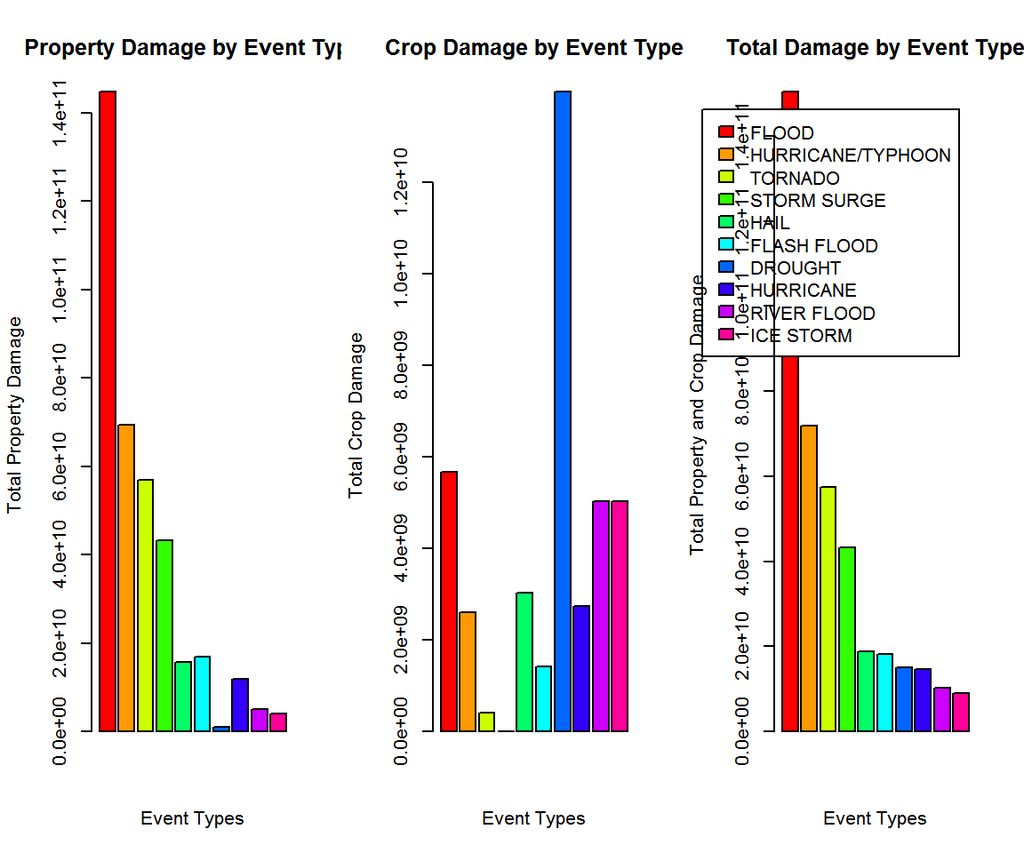

Top 10 Events Impacting the Economy in the United States

```r
par(mfrow=c(1,3))
barplot(dmgTop$TOT_PROPDMG, col = rainbow(10),
        xlab="Event Types", ylab="Total Property Damage",
        main="Property Damage by Event Type")
barplot(dmgTop$TOT_CROPDMG, col = rainbow(10),
        xlab="Event Types", ylab="Total Crop Damage",
        main="Crop Damage by Event Type")
barplot(dmgTop$TOT_DMG, legend.text = dmgTop$EVTYPE, col = rainbow(10),
        xlab="Event Types", ylab="Total Property and Crop Damage",
        main="Total Damage by Event Type")
```

```r
print(dmgTop)
```

```
## Source: local data frame [10 x 4]
##
##               EVTYPE  TOT_PROPDMG TOT_CROPDMG      TOT_DMG
##                (chr)        (dbl)       (dbl)        (dbl)
## 1              FLOOD 144657709807  5661968450 150319678257
## 2  HURRICANE/TYPHOON  69305840000  2607872800  71913712800
## 3            TORNADO  56947380677   414953270  57362333947
## 4        STORM SURGE  43323536000        5000  43323541000
## 5               HAIL  15735267513  3025954473  18761221986
## 6        FLASH FLOOD  16822673979  1421317100  18243991079
## 7            DROUGHT   1046106000 13972566000  15018672000
## 8          HURRICANE  11868319010  2741910000  14610229010
## 9        RIVER FLOOD   5118945500  5029459000  10148404500
## 10         ICE STORM   3944927860  5022113500   8967041360
```

In addition to that, it’s also worth looking at how often do these types of events occur to see what events can be prioritized in terms of preparing resources for.

```r
library(lubridate, warn.conflicts = FALSE)

byYearFatality <- group_by(weatherData, EVTYPE, year(BGN_DATE)) %>%
                  summarize(TOT_FATALITIES=sum(FATALITIES), TOT_INJURIES=sum(INJURIES),
                            AVG_FATALITIES=round(mean(FATALITIES), 4), AVG_INJURIES=round(mean(INJURIES), 4),
                            EVT_OCCURENCE=n())

byEventImpact <- group_by(byYearFatality, EVTYPE) %>%
                 summarize(TOT_IMPACT=sum(TOT_FATALITIES+TOT_INJURIES),
                           AVG_IMPACT=round(mean(AVG_FATALITIES+AVG_INJURIES), 4),
                           AVG_OCC=mean(EVT_OCCURENCE), TOT_OCC=sum(EVT_OCCURENCE)) %>%
                 filter(TOT_IMPACT!=0)
```